# Contact Sheets

25.11.2020

1. [28 Graphics for communication](https://r4ds.had.co.nz/graphics-for-communication.html):
   - [28.7.1 Figure sizing](https://r4ds.had.co.nz/graphics-for-communication.html#figure-sizing)

If you want to make sure the font size is consistent across all your figures, whenever you set out.width, you’ll also need to adjust fig.width to maintain the same ratio with your default out.width.

For example, if your default `fig.width` is 6 and `out.width` is 0.7, when you set `out.width = "50%"` you’ll need to set `fig.width` to 4.3 (6 * 0.5 / 0.7).

```
#> [1] 26.94688
#> [1] 13.299
```

[Using a Retina display](https://support.apple.com/en-us/HT202471), [dpilove](https://dpi.lv/#27″):

1. 27-inch iMac models introduced in 2014 or later. Native resolution: 5120 x 2880 (16:9) at 218 ppi (pixels per inch). Models introduced in 2014 and 2015 support millions of colors, and models introduced in 2017 or later support one billion colors. Approx. 23 x 13 in.
2. 13-inch MacBook Pro models introduced in late 2012 or later. Native resolution: 2560 x 1600 (16:10) at 227 ppi. Support for millions of colors. Approx 11 x 7 in.

[Taking Control of Plot Scaling](https://www.tidyverse.org/blog/2020/08/taking-control-of-plot-scaling/).

*iMac*, *MacBook Pro* width and height in cm

```r
c(3240, 1080) / 218        # in
```

```
#> [1] 14.862385  4.954128
```

```r
c(3240, 1080) / 218 * 2.54 # cm
```

```
#> [1] 37.75046 12.58349
```

```r
c(2160, 720) / 227         # in
```

```
#> [1] 9.515419 3.171806
```

```r
c(2160, 720) / 227 * 2.54  # cm
```

```
#> [1] 24.169163  8.056388
```

## Read Test and Train Tensors

```r
c(
  c(image_train, ., scat_train, vsat_train),
  c(image_test, ., scat_test, vsat_test)
) %<-% rraysplot::fat80_768x384
```

Check tensor dimensions.

```r
dim(image_train)
```

```
#> [1]  67 768 384
```

```r
dim(image_test)
```

```
#> [1]   9 768 384
```

```r
dimnames(image_test)[[1]]
```

```
#> [1] "1110505-2011" "158894-2018"  "163855"       "578317"       "648995-2014"
#> [6] "678810"       "690256"       "700120"       "801802"
```

```r
cat("\n")
dimnames(image_train)[[1]]
```

```
#>  [1] "1018642"     "1023660"     "1040979"     "1041204"     "1095912"
#>  [6] "1176610"     "1185364"     "158894-2016" "197929-2015" "254582-2014"
#> [11] "254582-2016" "281774-2018" "306001"      "306637"      "307629"
#> [16] "330238"      "376426"      "377549"      "387800"      "389728"
#> [21] "400295"      "415676"      "547766"      "552705"      "554667-2013"
#> [26] "554667-2014" "579124"      "600725-2019" "626604"      "648995-2011"
#> [31] "648995-2013" "661579"      "665924"      "683412-2015" "683412-2016"
#> [36] "683412-2019" "712846"      "715432"      "723887-2016" "723887-2018"
#> [41] "754337"      "764045"      "795905"      "797208"      "797610"
#> [46] "802551"      "803817"      "804568"      "835693"      "840780"
#> [51] "843037"      "853661"      "854387"      "871006"      "873863"
#> [56] "876730"      "878740"      "879820"      "882360-2016" "882360-2017"
#> [61] "883616"      "887603"      "894688"      "902756"      "914522"
#> [66] "918538"      "924243"
```

## Display Broken Images

```r
broken_test <- c("1110505-2012")
broken_train <- c("600725-2013", "806365", "858488")
```

| patient | kind | type | series | file_path |
| --- | --- | --- | --- | --- |
| 1110505-2012 | MRI | image_base | ../80_images | ../80_images/1110505-2012/image_base/1.2.840.19104.20483.007.1201.1.637400301058502819.dcm |

| patient | kind | type | series | file_path |
| --- | --- | --- | --- | --- |
| 600725-2013 | MRI | image_base | ../80_images | ../80_images/600725-2013/image_base/1.2.840.19104.20483.007.1201.1.637398387421023271.dcm |
| 806365 | MRI | image_base | ../80_images | ../80_images/806365/image_base/1.2.840.19104.20483.007.1201.1.637399389412120781.dcm |
| 858488 | MRI | image_base | ../80_images | ../80_images/858488/image_base/1.2.840.19104.20483.007.1201.1.637399399657433017.dcm |

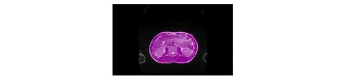

Test image: 1110505-2012

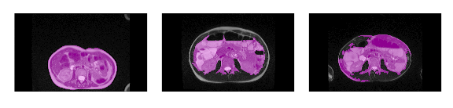

Train images: 600725-2013, 806365, 858488

*NOTE:* Only unbroken images tensors, i.e. with correct masks, are saved in `fat80_768x384`.